# First pass at predicting response from baseline samples in RTX trial

**J. Taroni 2018**

## Install `caret`

```r
# devtools::install_github('topepo/caret/pkg/caret',
#                          ref = "6546939345fe10649cefcbfee55d58fb682bc902")
# devtools::install_version("e1071", version = "1.6-8")
```

## Functions and directory set up

```r
# magrittr pipe
`%>%` <- dplyr::`%>%`
```

```r
# plot and result directory setup for this notebook
plot.dir <- file.path("plots", "25")
dir.create(plot.dir, recursive = TRUE, showWarnings = FALSE)
results.dir <- file.path("results", "25")
dir.create(results.dir, recursive = TRUE, showWarnings = FALSE)
```

## Read in data

#### Covariates

```r
covariate.df <- readr::read_tsv(file.path("data", "rtx",
                                          "RTX_full_covariates.tsv"))
```

#### Gene expression data

This is gene-level expression data that has been vst-transformed and filtered to only genes that are in the recount2 PLIER model.

```r
exprs <- readRDS(file.path("data", "rtx", "VST_blind_filtered.RDS"))
```

#### recount2 `B`

The multiPLIER approach

```r
recount.b <- readRDS(file.path("data", "rtx", "RTX_recount2_B.RDS"))
```

#### RTX PLIER model

```r
rtx.plier <- readRDS(file.path("data", "rtx", "RTX_PLIER_model.RDS"))
rtx.b <- rtx.plier$B
```

## LASSO

### Prep data

First, we’ll change the sample names to match the barcodes in the covariates. The first six characters of the current column/sample names should correspond to a barcode.

```r
# in the expression data
colnames(exprs) <- substr(colnames(exprs), start = 1, stop = 6)
all(covariate.df$barcode == colnames(exprs))
```

```
[1] TRUE
```

```r
# in the recount B data
colnames(recount.b) <- substr(colnames(recount.b), start = 1, stop = 6)
all(covariate.df$barcode == colnames(recount.b))
```

```
[1] TRUE
```

```r
# in the RTX B
colnames(rtx.b) <- substr(colnames(rtx.b), start = 1, stop = 6)
all(covariate.df$barcode == colnames(rtx.b))
```

```
[1] TRUE
```

The `mainclass` column in `covariate.df` is what we are interested in predicting; it contains whether or not a patient is a *nonresponder* or *responder* (divided into *tolerant* or *nontolerant* depending on, I believe, long-term outcome) to treatment. (We’ll exclude samples with `NA` in this column.)

We’ll want to try and predict this from baseline samples (`covariate.df$timepoint == "BL"`). We will not be adjusting for covariates at this point. The earlier publications on this trial suggest that the majority of covariates have no significant association with response.

Let’s take a look at the sample size and class balance.

```r
table(covariate.df$mainclass, covariate.df$timepoint)
```

```
               BL M18 M6
  Nonresponder 14  10  7
  Nontolerant  10   3 10
  Tolerant     12  12 12
```

```r
# Do all baseline samples have response labels? No, one is NA
baseline.covariate.df <- covariate.df %>%
  dplyr::filter(timepoint == "BL") %>%
  dplyr::select(c("barcode", "timepoint", "mainclass")) %>%
  dplyr::filter(complete.cases(.))
```

```r
# we only want the baseline samples with a class label
baseline.samples <- baseline.covariate.df$barcode
```

```r
baseline.exprs <- t(exprs[, which(colnames(exprs) %in% baseline.samples)])
dim(baseline.exprs)
```

```
[1]   36 6690
```

```r
recount.baseline.b <-
  t(recount.b[, which(colnames(recount.b) %in% baseline.samples)])
dim(recount.baseline.b)
```

```
[1]  36 987
```

```r
rtx.baseline.b <- t(rtx.b[, which(colnames(rtx.b) %in% baseline.samples)])
dim(rtx.baseline.b)
```

```
[1] 36 23
```

```r
all(rownames(recount.baseline.b) == baseline.covariate.df$barcode)
```

```
[1] TRUE
```

```r
all(rownames(baseline.exprs) == baseline.covariate.df$barcode)
```

```
[1] TRUE
```

```r
all(rownames(rtx.baseline.b) == baseline.covariate.df$barcode)
```

```
[1] TRUE
```

### Prediction

```r
set.seed(12345)
```

#### Expression data

```r
exprs.results <- glmnet::cv.glmnet(x = baseline.exprs,
                                   y = baseline.covariate.df$mainclass,
                                   type.measure = "class",
                                   family = "multinomial",
                                   nfolds = nrow(baseline.exprs))  # LOOCV
```

```
Option grouped=FALSE enforced in cv.glmnet, since < 3 observations per fold
```

```r
saveRDS(exprs.results, file.path(results.dir, "expression_cv.glmnet.RDS"))
```

```r
exprs.predicted.labels <- stats::predict(exprs.results,
                                         baseline.exprs,
                                         s = exprs.results$lambda.1se,
                                         type = "class")
caret::confusionMatrix(data = as.factor(exprs.predicted.labels),
                       reference = as.factor(baseline.covariate.df$mainclass))
```

```
Confusion Matrix and Statistics

              Reference
Prediction     Nonresponder Nontolerant Tolerant
  Nonresponder           13           1        0
  Nontolerant             0           9        0
  Tolerant                1           0       12

Overall Statistics

               Accuracy : 0.9444
                 95% CI : (0.8134, 0.9932)
    No Information Rate : 0.3889
    P-Value [Acc > NIR] : 2.763e-12

                  Kappa : 0.9157
 Mcnemar's Test P-Value : NA

Statistics by Class:

                     Class: Nonresponder Class: Nontolerant Class: Tolerant
Sensitivity                       0.9286             0.9000          1.0000
Specificity                       0.9545             1.0000          0.9583
Pos Pred Value                    0.9286             1.0000          0.9231
Neg Pred Value                    0.9545             0.9630          1.0000
Prevalence                        0.3889             0.2778          0.3333
Detection Rate                    0.3611             0.2500          0.3333
Detection Prevalence              0.3889             0.2500          0.3611
Balanced Accuracy                 0.9416             0.9500          0.9792
```

#### recount2 `B`

```r
recount.b.results <- glmnet::cv.glmnet(x = recount.baseline.b,
                                       y = baseline.covariate.df$mainclass,
                                       type.measure = "class",
                                       family = "multinomial",
                                       nfolds = nrow(recount.baseline.b))  # LOOCV
```

```
Option grouped=FALSE enforced in cv.glmnet, since < 3 observations per fold
```

```r
saveRDS(recount.b.results, file.path(results.dir, "recount2_B_cv.glmnet.RDS"))
```

```r
recount.b.predicted.labels <- stats::predict(recount.b.results,
                                             recount.baseline.b,
                                             s = recount.b.results$lambda.1se,
                                             type = "class")
caret::confusionMatrix(data = as.factor(recount.b.predicted.labels),
                       reference = as.factor(baseline.covariate.df$mainclass))
```

```
Levels are not in the same order for reference and data. Refactoring data to match.
```

```
Confusion Matrix and Statistics

              Reference
Prediction     Nonresponder Nontolerant Tolerant
  Nonresponder           14          10       12
  Nontolerant             0           0        0
  Tolerant                0           0        0

Overall Statistics

               Accuracy : 0.3889
                 95% CI : (0.2314, 0.5654)
    No Information Rate : 0.3889
    P-Value [Acc > NIR] : 0.5628

                  Kappa : 0
 Mcnemar's Test P-Value : NA

Statistics by Class:

                     Class: Nonresponder Class: Nontolerant Class: Tolerant
Sensitivity                       1.0000             0.0000          0.0000
Specificity                       0.0000             1.0000          1.0000
Pos Pred Value                    0.3889                NaN             NaN
Neg Pred Value                       NaN             0.7222          0.6667
Prevalence                        0.3889             0.2778          0.3333
Detection Rate                    0.3889             0.0000          0.0000
Detection Prevalence              1.0000             0.0000          0.0000
Balanced Accuracy                 0.5000             0.5000          0.5000
```

#### RTX `B`

```r
rtx.b.results <- glmnet::cv.glmnet(x = rtx.baseline.b,
                                   y = baseline.covariate.df$mainclass,
                                   type.measure = "class",
                                   family = "multinomial",
                                   nfolds = nrow(rtx.baseline.b))  # LOOCV
```

```
Option grouped=FALSE enforced in cv.glmnet, since < 3 observations per fold
```

```r
saveRDS(rtx.b.results, file.path(results.dir, "RTX_B_cv.glmnet.RDS"))
```

```r
rtx.b.predicted.labels <- stats::predict(rtx.b.results,
                                         rtx.baseline.b,
                                         s = rtx.b.results$lambda.1se,
                                         type = "class")
caret::confusionMatrix(data = as.factor(rtx.b.predicted.labels),
                       reference = as.factor(baseline.covariate.df$mainclass))
```

```
Confusion Matrix and Statistics

              Reference
Prediction     Nonresponder Nontolerant Tolerant
  Nonresponder           14           0        0
  Nontolerant             0          10        0
  Tolerant                0           0       12

Overall Statistics

               Accuracy : 1
                 95% CI : (0.9026, 1)
    No Information Rate : 0.3889
    P-Value [Acc > NIR] : 1.713e-15

                  Kappa : 1
 Mcnemar's Test P-Value : NA

Statistics by Class:

                     Class: Nonresponder Class: Nontolerant Class: Tolerant
Sensitivity                       1.0000             1.0000          1.0000
Specificity                       1.0000             1.0000          1.0000
Pos Pred Value                    1.0000             1.0000          1.0000
Neg Pred Value                    1.0000             1.0000          1.0000
Prevalence                        0.3889             0.2778          0.3333
Detection Rate                    0.3889             0.2778          0.3333
Detection Prevalence              0.3889             0.2778          0.3333
Balanced Accuracy                 1.0000             1.0000          1.0000
```

### Plotting accuracy

```r
acc.df <- data.frame(Model = c("Expression", "RTX LVs", "multiPLIER LVs"),
                     Accuracy = c(0.9444, 1, 0.3889),
                     Lower = c(0.8134, 0.9026, 0.2314),
                     Upper = c(0.9932, 1, 0.5654))
```

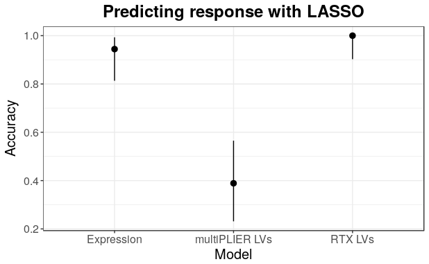

```r
acc.df %>%
  ggplot2::ggplot() +
  ggplot2::geom_pointrange(mapping = ggplot2::aes(x = Model, y = Accuracy,
                                                  ymin = Lower, ymax = Upper)) +
  ggplot2::theme_bw() +
  ggplot2::labs(title = "Predicting response with LASSO") +
  ggplot2::theme(plot.title = ggplot2::element_text(hjust = 0.5,
                                                    face = "bold")) +
  ggplot2::theme(text = ggplot2::element_text(size = 15))
```

```r
ggplot2::ggsave(file.path(plot.dir, "total_accuracy_CI.pdf"),
                plot = ggplot2::last_plot())
```

I wonder if the poor performance in the case of the multiPLIER LVs could be due to a smaller range of values.

```r
summary(as.vector(baseline.exprs))
```

```
   Min. 1st Qu.  Median    Mean 3rd Qu.    Max.
  3.399   6.428   8.460   8.419  10.282  19.637
```

```r
summary(as.vector(recount.baseline.b))
```

```
      Min.    1st Qu.     Median       Mean    3rd Qu.       Max.
-0.4666653 -0.0223182 -0.0020393 -0.0009504  0.0183729  0.8213279
```

```r
summary(as.vector(rtx.baseline.b))
```

```
     Min.   1st Qu.    Median      Mean   3rd Qu.      Max.
-2.612200 -0.470965 -0.123762  0.004056  0.327775  5.092082
```